# Carga de datos - Más fuentes de datos

Docente: Felipe Calvo Cepeda - fcalvoc@unal.edu.co | Universidad Nacional de Colombia

## Propósito de esta práctica

Esta práctica es opcional. Su propósito es reconocer que un flujo de datos puede comenzar en documentos, páginas web, imágenes o audio. Cada fuente requiere revisar licencia, estructura, calidad y significado.

## Lectura de PDF y texto

`pdftools` puede extraer texto de un PDF cuando el documento contiene texto seleccionable. Un PDF escaneado puede requerir OCR y producir errores de reconocimiento.

### Instalación de paquetes

```r
# Paquete para leer archivos en PDF
# install.packages("pdftools")

# Paquetes para minería de texto básica
# install.packages("tm")
# install.packages("wordcloud")
# install.packages("SnowballC")
```

### Importar paquetes y datos

```r
## Cargamos librerías
library(pdftools)
library(tm)
library(wordcloud)
library(SnowballC)

## Lectura
ruta_pdf = "data/Discurso-Roger.pdf"
pdf_text <- pdf_text(ruta_pdf)
```

### Minería de texto básica

```r
# Crear un vector de texto con el contenido de todas las páginas
pdf_text_combined <- paste(pdf_text, collapse = " ")

# Crear un corpus
corpus <- VCorpus(VectorSource(pdf_text_combined))

# Limpieza y preprocesamiento
corpus <- tm_map(corpus, content_transformer(tolower))      # Convertir todo en minúscula
corpus <- tm_map(corpus, removePunctuation)                 # Remover puntuaciones
corpus <- tm_map(corpus, removeNumbers)                     # Remover números
corpus <- tm_map(corpus, removeWords, stopwords("spanish")) # Remover stopwords (palabras vacías)
corpus <- tm_map(corpus, stemDocument)                      # Palabras madre
corpus <- tm_map(corpus, stripWhitespace)                   # Remover espacios extra

# Crear matriz de documento-términos
dtm <- DocumentTermMatrix(corpus)

# Convertir la matriz de documento-términos a una matriz de R
m <- as.matrix(dtm)

# Calcular frecuencia de palabras
word_freq <- sort(colSums(m), decreasing = TRUE)

# Crear un data frame con las palabras y sus frecuencias
word_freq_df <- data.frame(word = names(word_freq), freq = word_freq)

# Imprimir las frecuencias de las palabras
print(head(word_freq_df, 10))
```

```
##            word freq
## punto     punto    6
## talento talento    6
## partido partido    5
## perdí     perdí    5
## así         así    4
## grand     grand    4
## mundo     mundo    4
## teni       teni    4
## vece       vece    4
## apena     apena    3
```

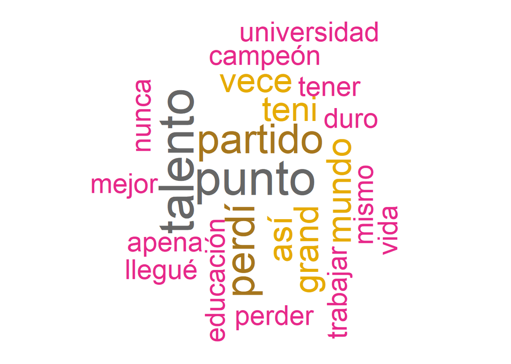

```r
# Crear una nube de palabras
set.seed(1234)
wordcloud(words = word_freq_df$word, freq = word_freq_df$freq, min.freq = 3,
          max.words = 100, random.order = FALSE, rot.per = 0.35,
          colors = brewer.pal(8, "Dark2"))
```

## Lectura de páginas web

### Instalación de paquetes

```r
# Paquetes para leer páginas web
# install.packages("rvest")
# install.packages("xml2")
```

### Cargo datos basado en un ID

```r
# Cargo paquete
library(rvest)
# Defino URL de la página web que deseo leer
pagina_local <- read_html("https://felipe-calvo.github.io/r-101/p1-setup.html")
# Extraigo los títulos de la página web bajo la etiqueta <h2>
titulos <- pagina_local |>
  html_elements("h2") |>
  html_text2()

# Muestros los títulos extraídos
titulos
```

```
##  [1] "Propósito de esta práctica"
##  [2] "¿Qué es R?"
##  [3] "¿Por qué nos gusta R?"
##  [4] "R es particularmente útil para"
##  [5] "Advertencias"
##  [6] "Instalación de R"
##  [7] "Interfaces de usuario (GUI) e instalación de RStudio Desktop"
##  [8] "Crear un proyecto"
##  [9] "Paquetes: instalar una vez, cargar muchas veces"
## [10] "Correr comandos/código"
## [11] "Actualizar R y los paquetes (si ya lo tenía instalado)"
## [12] "Buenas prácticas"
## [13] "IA como asistente de programación"
## [14] "Informes automáticos"
## [15] "Lista de verificación"
```

Para una fuente externa debe guardar la URL, la fecha de consulta, el selector utilizado y, cuando sea posible, una copia autorizada del contenido. No haga scrapping de sitios que prohíban el acceso automatizado ni recolecte datos personales sin autorización.

```r
pagina <- read_html("https://ejemplo.org/pagina")
contenido <- pagina |>
  html_elements("article") |>
  html_text2()
```

## Lectura de archivos de audio

La lectura de audio es un módulo de ampliación. El archivo debe estar disponible localmente y su formato debe ser compatible con el paquete.

### Instalación de paquetes

```r
# Paquetes para lectura y procesamiento básico de audio
# install.packages("tuneR")
# install.packages("seewave")
```

### Lectura de datos

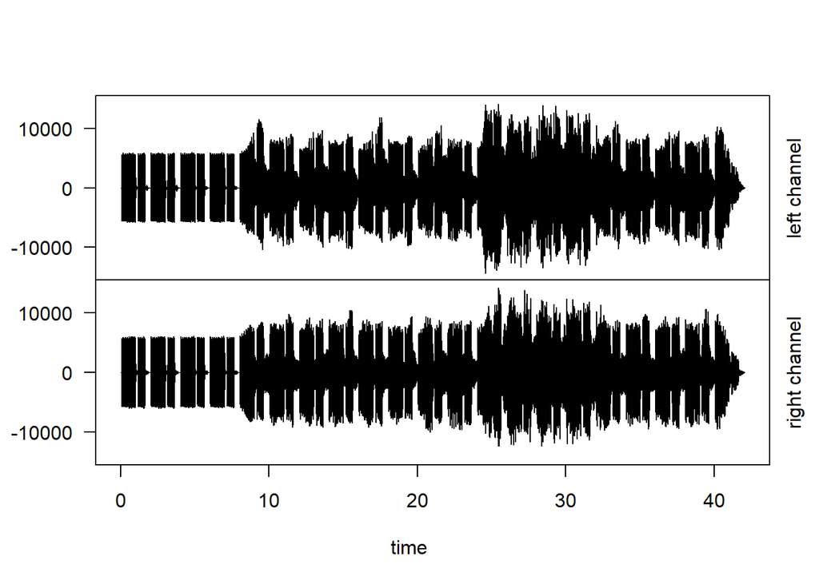

```r
library(tuneR)
library(seewave)

# Especifica la ruta al archivo MP3
archivo_mp3 <- "data/ejemplo_audio.mp3"

# Leer el archivo MP3
audio <- readMP3(archivo_mp3)

# Hacemos algo
plot(audio)
```

El análisis de audio requiere documentar frecuencia de muestreo, canales, duración y transformaciones. No se deben publicar grabaciones de voz sin autorización.

Un ejemplo de procesamiento de audio podría ser la transcripción de voz a texto.

## Lectura de imágenes

Una imagen puede ser un resultado visual o una fuente de datos. En este ejemplo leemos un recurso del curso y comprobamos sus dimensiones.

### Instalación de paquetes

```r
# Paquetes para leer imágenes
# install.packages("jpeg")
# install.packages("png")
# install.packages("magick")
```

### Lectura de datos

```r
library(png)
imagen <- readPNG("img/distribuciones.png")
dim(imagen)
```

```
## [1]  619 1274    4
```

Si se requiere manipulación, `magick` permite cambiar tamaño, formato o metadatos. Al trabajar con imágenes de personas deben considerarse consentimiento, privacidad y licencia.

```r
# install.packages("magick")
library(magick)
imagen_magick <- image_read("img/distribuciones.png")
image_info(imagen_magick)
```

```
##   format width height colorspace matte filesize density
## 1    PNG  1274    619       sRGB  TRUE   143163   47x47
```

## Práctica opcional

Elija una fuente no tabular y entregue:

1. La fuente original y su licencia o condición de uso.
2. Un script que extraiga o lea la información.
3. Una transformación que produzca una tabla.
4. Una visualización o resumen.

## Lista de verificación

- La fuente es accesible y su fecha de consulta está registrada.
- El código falla de manera comprensible si el archivo no existe.
- Se distingue extracción de datos, limpieza e interpretación.
- Se respetan privacidad, derechos de autor y términos de uso.